# Milestone Report Data Science Capstone. Johns Hopkins University

jc

8/13/2020

### Executive Summary

In this report we present an introductory exploration over the SwiftKey datasets for the english language (US). We calculate some statistics about the files and also the frequencies over different n-grams. We also show the coverage given a sample of Data.

# Peer-graded Assignment: Milestone Report

The goal of this project is just to display that you’ve gotten used to working with the data and that you are on track to create your prediction algorithm. Please submit a report on R Pubs (http://rpubs.com/) that explains your exploratory analysis and your goals for the eventual app and algorithm. This document should be concise and explain only the major features of the data you have identified and briefly summarize your plans for creating the prediction algorithm and Shiny app in a way that would be understandable to a non-data scientist manager. You should make use of tables and plots to illustrate important summaries of the data set. The motivation for this project is to:

1. Demonstrate that you’ve downloaded the data and have successfully loaded it in.
2. Create a basic report of summary statistics about the data sets.
3. Report any interesting findings that you amassed so far.
4. Get feedback on your plans for creating a prediction algorithm and Shiny app.

## Data Acquisition and Preparation

**1. Demonstrate that you’ve downloaded the data and have successfully loaded it in.**

We found the following packages useful:

[tokenizers](https://cran.r-project.org/web/packages/tokenizers/vignettes/introduction-to-tokenizers.html)

[readr](https://readr.tidyverse.org/)

[tm](https://cran.r-project.org/web/packages/tm/tm.pdf)

```r
downloadFinalProjectFile <- function(){
  fileUrl <- "https://d396qusza40orc.cloudfront.net/dsscapstone/dataset/Coursera-SwiftKey.zip"
  destinationPath <- "./data/Coursera-SwiftKey.zip"

  if(!file.exists("./data")){
      dir.create("./data")
    }

  if(!file.exists("./data/Coursera-SwiftKey.zip")){
    download.file(fileUrl, destfile = destinationPath, method = "curl")  #for binary files.
  }
  else
  {
    print("Source files has already been downloaded! will place the new one in the backup folder in data.")
    dir.create("./data/backup")
    download.file(fileUrl, destfile = "./data/backup/Coursera-SwiftKey.zip", method = "curl")
  }
  dateDownloaded <- date()
  unzip( destinationPath, exdir="./data", list =TRUE)
}

downloadFinalProjectFile()
```

Once the Data is obtained we proceed to load all data. We have chosen to read all files and integrate them into a single data source.

```r
# Returns all lines in the file:
readFullFile <- function(inFile)
{
  # con <- file(file.choose(), "r")
  # setwd()
  # list.files()

  connection <- file(inFile, "r")

  totalData <- readLines(connection, encoding = "UTF-8", skipNul = TRUE)
  # with readLines(connection, n =1) you can read line by line avoiding to store all data in memory!

  close(connection)

  return(totalData)
}

suppressMessages( library(tm) )
suppressMessages( library(ggplot2))
suppressMessages( library(wordcloud))
suppressMessages( library(quanteda))
options(warn=-1)

### Read all files at once
fullDataUSTwitter <- readFullFile("./data/final/en_US/en_US.twitter.txt")
fullDataUSBlogs <- readFullFile("./data/final/en_US/en_US.blogs.txt")
fullDataUSNews <- readFullFile("./data/final/en_US/en_US.news.txt")
```

We could have done all the previous operations by reading the Data line by line. The advantage of such approach would be low main memory consumption but at the gruesome cost of higher elapsed time.

## Exploratory Analysis

**2. Create a basic report of summary statistics about the data sets.**

**3. Report any interesting findings that you amassed so far.**

Initially, we need to consider the dimmensions between all dataset files we have:

```
##    Counts           File
## 1  899288   US_Blogs.txt
## 2 1010242    US_News.txt
## 3 2360148 US_Twitter.txt
```

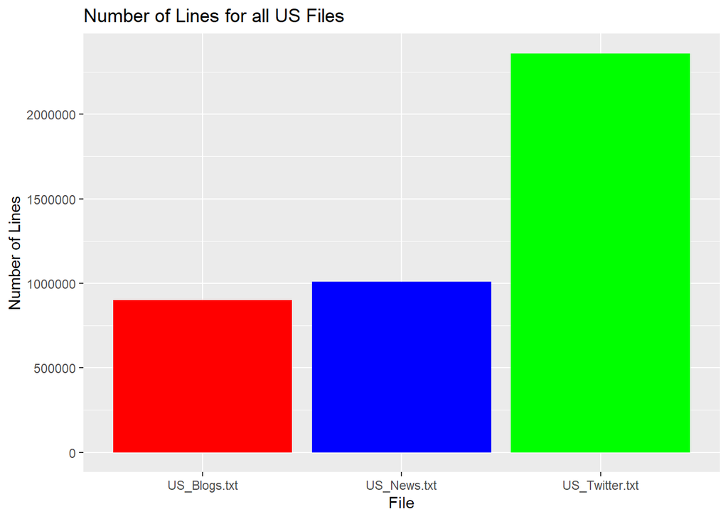

```r
displayNumberOfLinesBarPlot <- function(){
  suppressMessages(library(ggplot2))

  dataPath <- "./data/final/en_US/"
  source("readData.R")
  numberLinesBlogs <- readTotalNumberOfLinesInFile(paste0(dataPath, "en_US.blogs.txt"))
  numberLinesNews <- readTotalNumberOfLinesInFile(paste0(dataPath, "en_US.news.txt"))
  numberLinesTwitter <- readTotalNumberOfLinesInFile(paste0(dataPath, "en_US.twitter.txt"))

  df <- data.frame( c(numberLinesBlogs, numberLinesNews, numberLinesTwitter))
  df$File <- c("US_Blogs.txt", "US_News.txt", "US_Twitter.txt")
  colnames(df)[1] <- "Counts"
  colors1 <- c("red", "blue", "green")

  print(df)

  ggplot(df, aes(x=File, y=Counts)) + geom_bar(stat='identity', fill = colors1) + ylab("Number of Lines") + xlab("File") + ggtitle("Number of Lines for all US Files")
}

displayNumberOfLinesBarPlot()
```

We observe that the twitter file is the largest:

```r
printLengthsOfFilesTable <- function(){
  dataPath <- "./data/final/en_US/"
  source("readData.R")
  numberLinesBlogs <- readTotalNumberOfLinesInFile(paste0(dataPath, "en_US.blogs.txt"))
  numberLinesNews <- readTotalNumberOfLinesInFile(paste0(dataPath, "en_US.news.txt"))
  numberLinesTwitter <- readTotalNumberOfLinesInFile(paste0(dataPath, "en_US.twitter.txt"))

  df <- data.frame( Total.Lines = c(numberLinesBlogs, numberLinesNews, numberLinesTwitter))
  df$File <- c("US_Blogs.txt", "US_News.txt", "US_Twitter.txt")

  # print(df)

  knitr::kable(df, col.names = gsub("[.]", " ", names(df)))
}

printLengthsOfFilesTable ()
```

| Total Lines | File |
| --- | --- |
| 899288 | US_Blogs.txt |
| 1010242 | US_News.txt |
| 2360148 | US_Twitter.txt |

It is necessary to review the size of each file in Mbs as well to have an impression of the density of lines in each file:

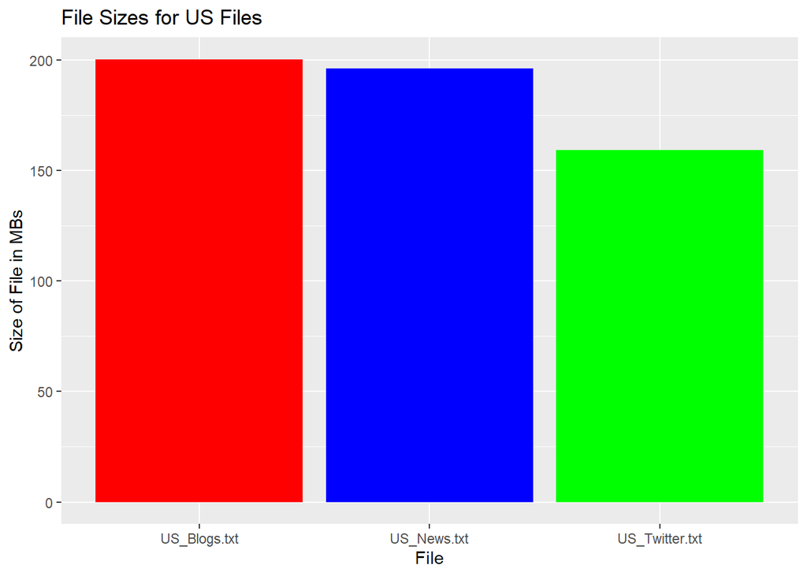

```r
displaySizeOfFilesBarPlot <- function(){
  dataPath <- "./data/final/en_US/"

  sizeBlogs <- (file.info(paste0(dataPath, "en_US.blogs.txt"))$size)
  sizeNews <- (file.info(paste0(dataPath, "en_US.news.txt"))$size)
  sizeTwitter <- (file.info(paste0(dataPath, "en_US.twitter.txt"))$size)

  df <- data.frame( c(sizeBlogs/1024/1024, sizeNews/1024/1024, sizeTwitter/1024/1024))
  df$File <- c("US_Blogs.txt", "US_News.txt", "US_Twitter.txt")
  colnames(df)[1] <- "Size"
  colors1 <- c("red", "blue", "green")
  # print(df)

  ggplot(df, aes(x=File, y=Size)) + geom_bar(stat='identity', fill = colors1) + ylab("Size of File in MBs") + xlab("File") + ggtitle("File Sizes for US Files")
}

displaySizeOfFilesBarPlot()
```

```r
displaySizeOfFilesTable <- function(){
  dataPath <- "./data/final/en_US/"

  sizeBlogs <- (file.info(paste0(dataPath, "en_US.blogs.txt"))$size)
  sizeNews <- (file.info(paste0(dataPath, "en_US.news.txt"))$size)
  sizeTwitter <- (file.info(paste0(dataPath, "en_US.twitter.txt"))$size)

  df <- data.frame( c(sizeBlogs/1024/1024, sizeNews/1024/1024, sizeTwitter/1024/1024))
  df$File <- c("US_Blogs.txt", "US_News.txt", "US_Twitter.txt")
  colnames(df)[1] <- "Size in MBs"

  # print(df)
  knitr::kable(df, col.names = gsub("[.] ", " ", names(df)))
}

displaySizeOfFilesTable()
```

| Size in MBs | File |
| --- | --- |
| 200.4242 | US_Blogs.txt |
| 196.2775 | US_News.txt |
| 159.3641 | US_Twitter.txt |

Interestingly enough we can see that the blogs and news files are larger in Byte size than the twitter ones. This is logical since twitter has a fixed length of characters per tweet whereas in the other cases the length of the posts is open for the writer.

In order to check the later assumption we will find some relevant statistics regarding the lines in the files:

```r
displayLineStatisticsForFiles <- function(){

  df <- data.frame( File = character(), Maximum.Number.Of.Characters = numeric(), Total.Number.Of.Words = numeric())

  nchars <- lapply(fullDataUSTwitter, nchar)
  maxchars <- which.max(nchars)
  wordCount <- sum(sapply(strsplit(fullDataUSTwitter, "\\s+"), length))

  df <- rbind(df, c("en_US.twitter.txt", maxchars, wordCount) )

  nchars <- lapply(fullDataUSBlogs, nchar)
  maxchars <- which.max(nchars)
  wordCount <- sum(sapply(strsplit(fullDataUSBlogs, "\\s+"), length))

  df <- rbind(df, c("en_US.blogs.txt", maxchars, wordCount) )

  nchars <- lapply(fullDataUSNews, nchar)
  maxchars <- which.max(nchars)
  wordCount <- sum(sapply(strsplit(fullDataUSNews, "\\s+"), length))

  df <- rbind(df, c("en_US.news.txt", maxchars, wordCount) )

  colnames(df) <- c("File", "Maximum.Number.Of.Words.In.A.Line", "Total.Number.Of.Words")

  #print(df)
  knitr::kable(df, col.names = gsub("[.] ", " ", names(df)))
}

displayLineStatisticsForFiles()
```

[output not shown]

### Cleaning Up the Data

We form the Corpus and remove all unnecessary features from Data. We also sample the Data in order to have a faster analisis, however we may as well include all contents with all lines for the analysis. We also apply a censorship function in order to remove all bad words, punctuations or other features we decided irrelvant for this project. The list of obscene words was taken from the repository https://raw.githubusercontent.com/LDNOOBW/List-of-Dirty-Naughty-Obscene-and-Otherwise-Bad-Words/master/en.

The following function make it possible:

```r
## These functions are meant to be used for any dataset

suppressMessages( library(tm) )

createCorpus <- function(textData_in_Memory){
  corpora <- paste(textData_in_Memory, collapse=" ")
  corpora <- VectorSource(corpora)
  corpora <- Corpus(corpora)

  return(corpora)
}

cleanCorpus <- function(rawCorpus) {

  rawCorpus <- tm_map(rawCorpus, content_transformer(tolower))

  toSpace <- content_transformer(function(x, pattern) gsub(pattern, " ", x))
  rawCorpus <- tm_map(rawCorpus, toSpace, "/|@|//|$|:|:)|*|&|!|?|_|-|#|")

  rawCorpus <- tm_map(rawCorpus, removeNumbers)
  rawCorpus <- tm_map(rawCorpus, removeWords, stopwords("english"))
  rawCorpus <- tm_map(rawCorpus, removePunctuation)
  rawCorpus <- tm_map(rawCorpus, stripWhitespace)

  source("badwords.R")
  rawCorpus <- tm_map(rawCorpus, removeWords, VectorSource(badwords))

  #rawCorpus <- tm_map(rawCorpus, stemDocument)

  return (rawCorpus)
}
```

### Word Frequency

We consider the top 25 words that we found over a sampled subset of the original Data from merging the three datasets. We set a variable to extract only a percentage of lines from the original file (trying to practice a sampling task, however we may as well consider all data for exploratory analisis since no performance issues are critical in this case). We then show a plot containing the frequencies of most used words.

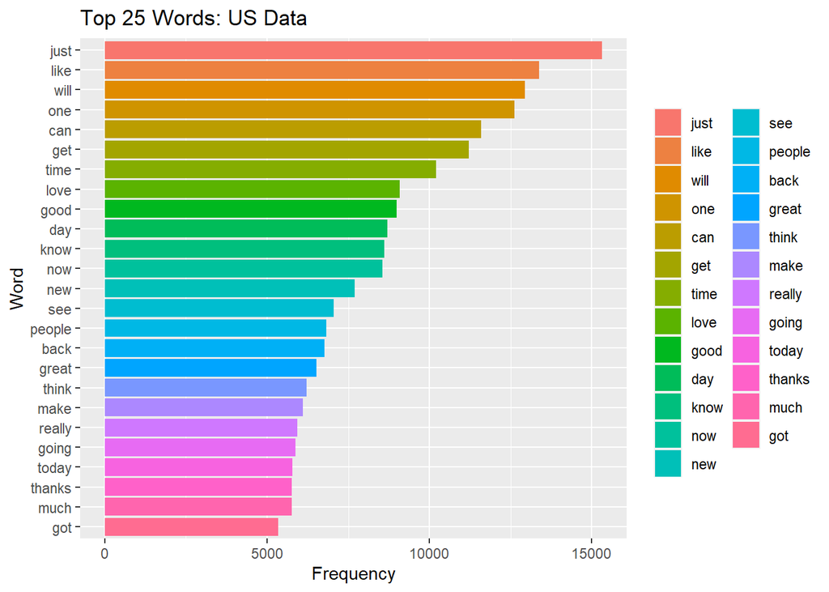

```r
suppressMessages( library(ggplot2))
options(warn=-1)
## Obtain all frequencies for all words in the Corpus

calculateFrequencyOfWords <- function (theCorpus) {
  csparse <- DocumentTermMatrix(theCorpus)
  cmatrix <- as.matrix(csparse)

  wordFrequencies <- colSums(cmatrix)
  wordFrequencies <- as.data.frame(sort(wordFrequencies, decreasing=TRUE))
  wordFrequencies$word <- rownames(wordFrequencies)
  colnames(wordFrequencies) <- c("Frequency", "Word")

  return (wordFrequencies)
}

  ### Sample the Data
  set.seed(13)
  sampleSizePercentage <- .06    # For each file we sample the given percentage of lines (from 0 to 1, e.g. .6 is sixty percent).

  sampledDataUSTwitter <- sample(fullDataUSTwitter, round(sampleSizePercentage*length(fullDataUSTwitter)), replace = F)
  sampledDataUSBlogs <- sample(fullDataUSBlogs, round(sampleSizePercentage*length(fullDataUSBlogs)), replace = F)
  sampledDataUSNews <- sample(fullDataUSNews, round(sampleSizePercentage*length(fullDataUSNews)), replace = F)

  ### Optional, we may as well use any sampled subset (sampledDataUSTwitter, sampledDataUSBlogs, sampledDataUSNews)
  ### This decision has to take into consideration other factors to be investigated outside the raw Data. e.g. Expert opinion.
  sampledDataTwitterBlogsNews <- c(sampledDataUSTwitter, sampledDataUSBlogs, sampledDataUSNews)

  textData <- sampledDataTwitterBlogsNews

  USCorpus <- createCorpus(textData)
  USCorpus <- cleanCorpus(USCorpus)

  allWordFrequencies <- calculateFrequencyOfWords(USCorpus)
  top25Words <- allWordFrequencies[1:25,]

  #Plot results of word frequencies
  p <- ggplot(data=top25Words, aes(x=reorder(Word,Frequency), y=Frequency,
               fill=factor(reorder(Word,-Frequency))))+ geom_bar(stat="identity")
  p + xlab("Word") +labs(title = "Top 25 Words: US Data") +theme(legend.title=element_blank()) + coord_flip()
```

We present the results in a graphic manner as a word cloud with the top 100 most used words:

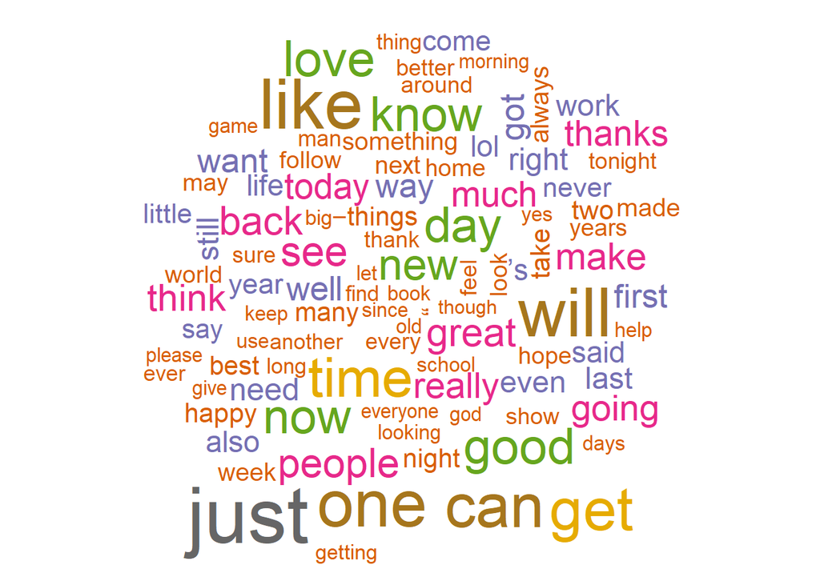

```r
# Show a word Cloud for the 100 most used words
suppressMessages( library(wordcloud))
wordcloud(allWordFrequencies$Word[1:100], allWordFrequencies$Frequency[1:100], colors=brewer.pal(8, "Dark2"))
```

### N-gram Analysis

According to https://en.wikipedia.org/wiki/N-gram an n-gram is a contiguous sequence of n items from a given sample of text or speech. The items can be phonemes, syllables, letters, words or base pairs according to the application. The n-grams typically are collected from a text or speech corpus. When the items are words, n-grams may also be called shingles. Using Latin numerical prefixes, an n-gram of size 1 is referred to as a “unigram”; size 2 is a “bigram” (or, less commonly, a “digram”); size 3 is a “trigram”.

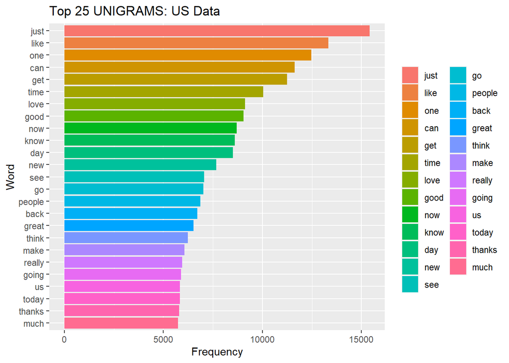

```r
### Calculate the unigrams, bigrams and trigrams using this generalized function version for an n-gram
suppressMessages( library(quanteda))
getN_grams <- function(textData_in_Memory, numberOfGrams){
  theTokens<- tokens(textData_in_Memory,what ="word", remove_numbers = TRUE, remove_punct = TRUE,
                     remove_separators = TRUE, remove_symbols = TRUE )
  theTokens <- tokens_tolower(theTokens)
  theTokens <- tokens_select(theTokens, stopwords(), selection ="remove")

  unigram <- tokens_ngrams(theTokens, n = numberOfGrams)
  unigram.dfm <- dfm(unigram, tolower =TRUE, remove = stopwords("english"), remove_punct = TRUE)

  return( unigram.dfm )
}

numberOfWords = 25
  #Obtain the top N Unigrams
  unigrams <- getN_grams( textData, 1)
  unigramsDf <- stack(topfeatures(unigrams, numberOfWords))
  unigramsDf <- setNames(stack(topfeatures(unigrams, numberOfWords))[2:1], c('Words','Frequency'))

  p <- ggplot(data=unigramsDf, aes(x=reorder(Words,Frequency), y=Frequency,
                                   fill=factor(reorder(Words,-Frequency))))+ geom_bar(stat="identity")
  p + xlab("Word") +labs(title = "Top 25 UNIGRAMS: US Data") +theme(legend.title=element_blank()) + coord_flip()
```

Now, we count the top 25 bigrams:

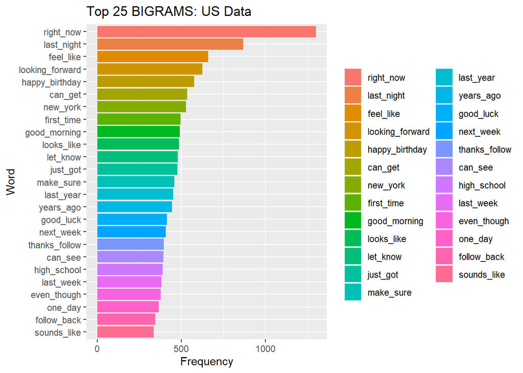

```r
#Obtain the Bigrams
  bigrams <- getN_grams( textData, 2)
  bigramsDf <- stack(topfeatures(bigrams, numberOfWords))
  bigramsDf <- setNames(stack(topfeatures(bigrams, numberOfWords))[2:1], c('Words','Frequency'))

  p <- ggplot(data=bigramsDf, aes(x=reorder(Words,Frequency), y=Frequency,
                                   fill=factor(reorder(Words,-Frequency))))+ geom_bar(stat="identity")
  p + xlab("Word") +labs(title = "Top 25 BIGRAMS: US Data") +theme(legend.title=element_blank()) + coord_flip()
```

Finally we obtain the frequencies for the trigrams:

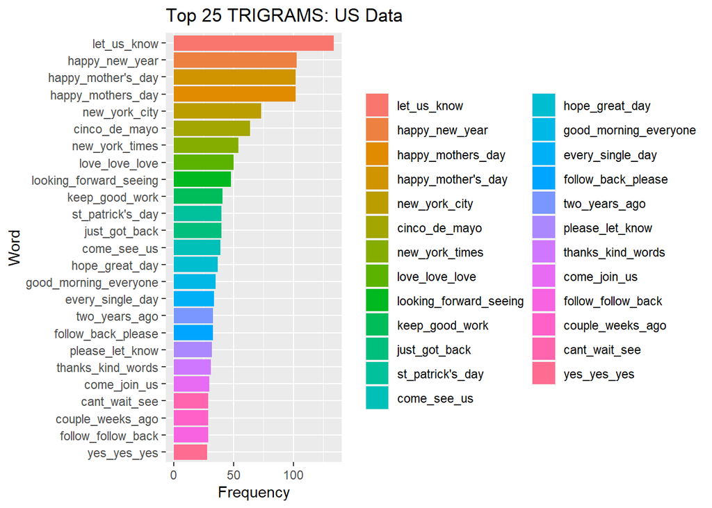

```r
#Obtain the Trigrams
  trigrams <- getN_grams( textData, 3)
  trigramsDf <- stack(topfeatures(trigrams, numberOfWords))
  trigramsDf <- setNames(stack(topfeatures(trigrams, numberOfWords))[2:1], c('Words','Frequency'))

  p <- ggplot(data=trigramsDf, aes(x=reorder(Words,Frequency), y=Frequency,
                                  fill=factor(reorder(Words,-Frequency))))+ geom_bar(stat="identity")
  p + xlab("Word") +labs(title = "Top 25 TRIGRAMS: US Data") +theme(legend.title=element_blank()) + coord_flip()
```

### Coverage

In the following plot we can obtain the coverage for 50% and 90% by checking the x axis (for completeness we show all other percentages):

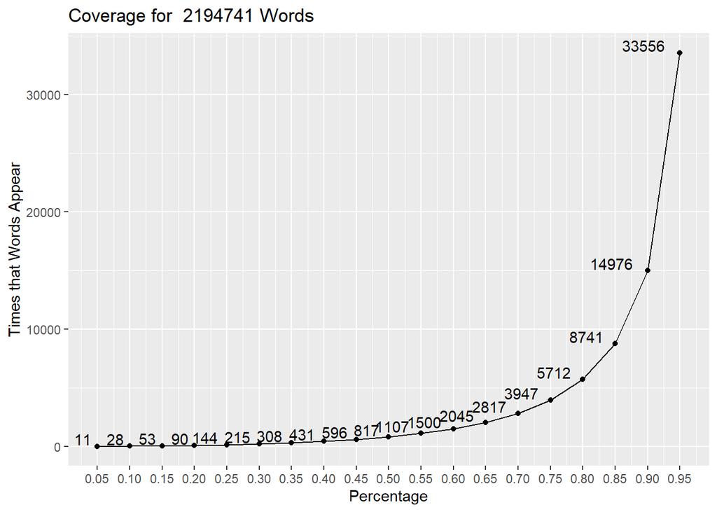

```r
### Calculate Coverage. You receive a corpus and in turn the function obtains how many words are needed to cover a given percentage of the full corpus.
getCoverage <- function(theCorpus, percentage){


  allWordFrequencies <- calculateFrequencyOfWords(theCorpus)
  totalNumberOfWords <- sum(allWordFrequencies$Frequency)

  currentPercentage <- 0
  counter <- 1
  numberOfWords <- 0

  while(currentPercentage < percentage){
    numberOfWords <- numberOfWords + allWordFrequencies$Frequency[counter]
    currentPercentage <- numberOfWords / totalNumberOfWords

    counter <- counter + 1
  }

  return(counter)
}

#Obtain coverage for any given percentage
  percents <- seq(from = .05, to =.95, by = .05)
  wordCovers <- c()

  for (i in 1:length(percents)){
    wordCovers <- c(wordCovers, getCoverage(USCorpus, percents[i]))
  }

  q <- qplot(percents,wordCovers, geom=c("line","point")) + geom_text(aes(label=wordCovers), hjust=1.35, vjust=-0.1)+ xlab("Percentage") + ylab("Times that Words Appear") + labs(title = paste( "Coverage for ", sum(allWordFrequencies$Frequency), "Words"))
  q +scale_x_continuous(breaks=percents)
```

### Discussion

As a first approach in order to evaluate words that come from foreign languages, we may access a dictionary or idiom list for that language, then we could either remove them from the corpus or identify them as foreign words.

We may use another machine learning method to learn the vocabulary and habits of the user in order to offer a more personalized prediction and thus, increasing coverage. The coverage of other spatio temporal features such as location: We may also use location services in order to recommend nearby places or other features that might be of interest. Finally, we may learn the relationship between stopwords and other nouns and verbs that might be correlated.

**4. Get feedback on your plans for creating a prediction algorithm and Shiny app.**

Please leave your feedback in the comments section. Thanks!